# Robust Extrinsic Local Regression

Hwiyoung Lee

Last Updated - Oct 7, 2020

## Introduction

This project page briefly introduces the methodology described in the paper.

- Lee, H. and Patrangenaru, V. (2020). *Robust Extrinsic Regression Analysis for Manifold Valued Data*
- Github repository : RELR

## Motivation

Consider two location measures

- **Mean** :
  $$\begin{align*}
  \bar{\bf{x}} &= \operatorname{argmin}_{\bf{q}\in\mathbb{R}^p}\sum_{i=1}^n \Vert\bf{x}_i - \bf{q}\Vert^2 \\
  &= \sum_{i=1}^n\frac{\bf{x}_i}{n}
  \end{align*}$$
  - The mean is overly influenced by outliers
- **Geometric Median** :
  $$\begin{align*}
  \bf{m} = \operatorname{argmin}_{\bf{q}\in\mathbb{R}^p}\sum_{i=1}^n \Vert\bf{x}_i - \bf{q}\Vert
  \end{align*}$$
  - Robust to outliers, also known as the facility location problem
  - But, doesn't have a closed form solution

Toy example

Generate random numbers on $\mathbb{R}^2$ and impose some outliers.

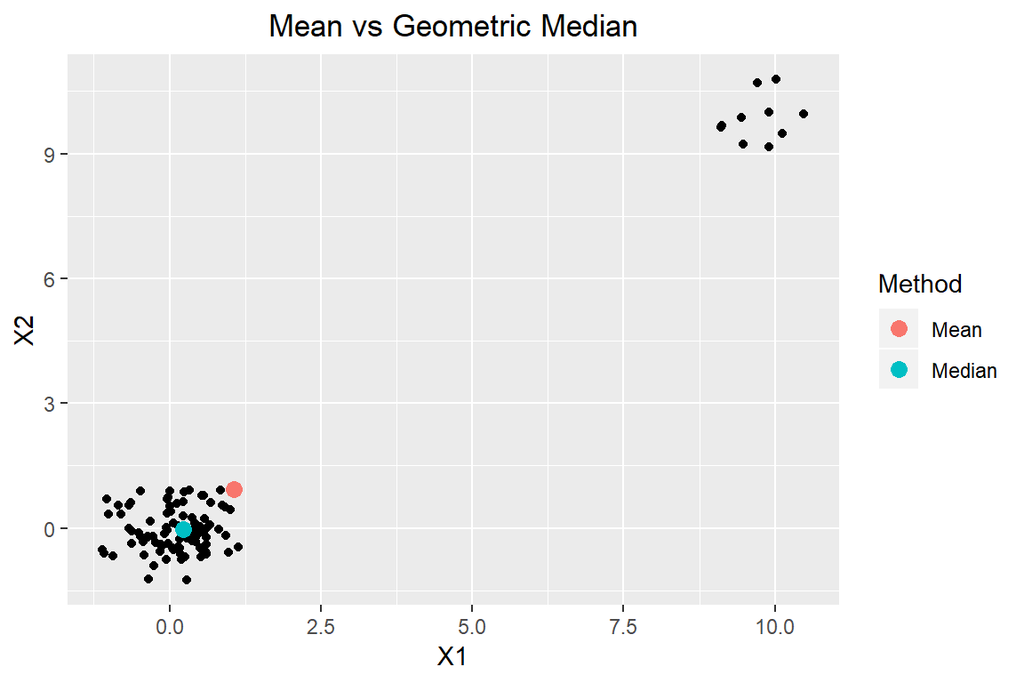

```r
N       <- 100      # Number of Data
n.out   <-  10      # Number of Outliers
X1      <- rnorm(N,0,0.5)
X2      <- rnorm(N,0,0.5)
X1[c(1:n.out)] <- X1[c(1:n.out)]+10
X2[c(1:n.out)] <- X2[c(1:n.out)]+10
```

## Extrinsic Median

### Definition

- **Population extrinsic median** : Consider the unsquared Euclidean norm induced by $J : \mathcal{M} \rightarrow E^d$
  $$\begin{align*}
  {\bf{m}_E} = \operatorname{argmin}_{{\bf{q}}\in\mathcal{M}}\int_\mathcal{M} \Vert J( {\bf{x}}) - J( {\bf{q}}) \Vert P(d\bf{x})
  \end{align*}$$
- **Empirical extrinsic median** : Suppose $\bf{x}_1, \cdots, \bf{x}_n$ are i.i.d copies of $\mathcal{M}$ valud r.v. $\bf{X}$.
  $$\begin{align*}
  \bf{\hat{m}}_E &= \operatorname{argmin}_{\bf{q}\in\mathcal{M}} \sum_{i=1}^n \Vert J({\bf{x_i}})-J(\bf{q}) \Vert\\
  &= J^{-1} \left( \mathcal{P} \left(\operatorname{argmin}_{m \in E^d} \sum_{i=1}^n \Vert J(\bf{x}_i)-m \Vert \right)\right),
  \end{align*}$$
  where $\mathcal{P} : E^d \rightarrow J(\mathcal{M})$ is the projection onto the image of the embedding.

Q. How to solve the above problem ? **Weiszfeld's Algorithm**

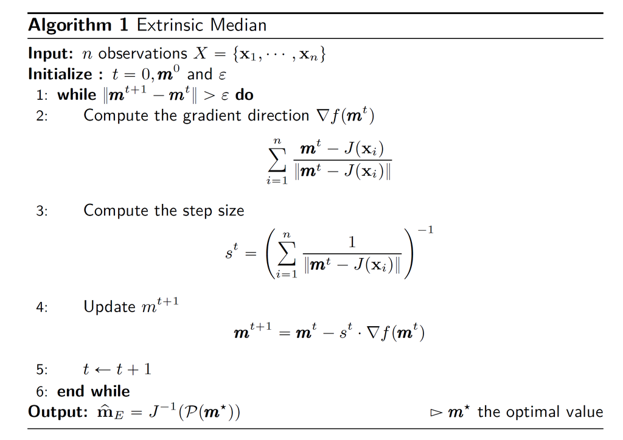

### Applications

#### 1. Circle

Consider two different situations

- Scenario 1 : von Mises distribution contaminated with outliers
  $$\begin{align*}
  f(\theta) = \frac{e^{\kappa\cos(\theta-\mu)}}{2\pi I_0(\kappa)},
  \end{align*}$$

  where $I_0(\kappa)$ is the modified Bessel function of order 0. We add outliers using normal dist $N(\mu_{\text{out}}, \sigma^2)$, where $\mu_{\text{out}} \neq \mu$
- Scenario 2 : Wrapped $\alpha$ stable distribution
  $$\begin{align*}
  f(\theta) = \frac{1}{2\pi} + \frac{1}{\pi} \sum_{k=1}^\infty \exp(-\tau^\alpha k^\alpha)\cos \left( k(\theta-\mu) -\tau^\alpha k^\alpha \beta \tan \frac{\alpha \pi}{2} \right),
  \end{align*}$$

  where $\tau \geq 0$ and $\vert\beta\vert \leq 1$ denote the scale and skewness parameter, respectively.

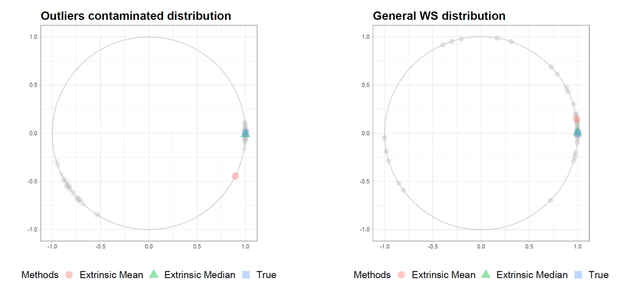

#### 2. Planar Shape

- Investigate a subset of ADHD-200 dataset (http://fcon_1000.projects.nitrc.org/indi/adhd200/)
- Impose outliers to the real part ($x$ coordinate) of the 10th - 15th landmakrs.

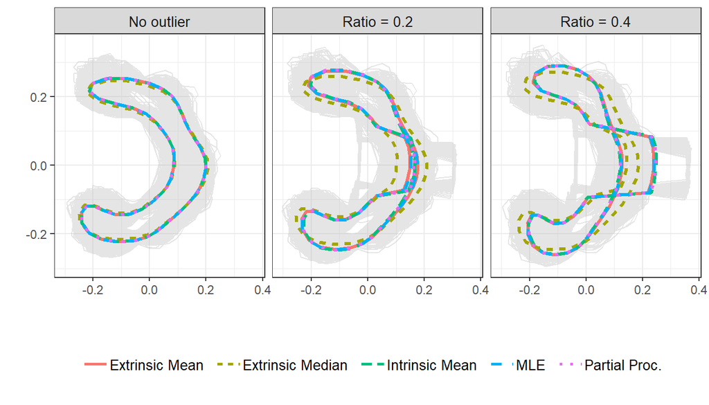

- Result

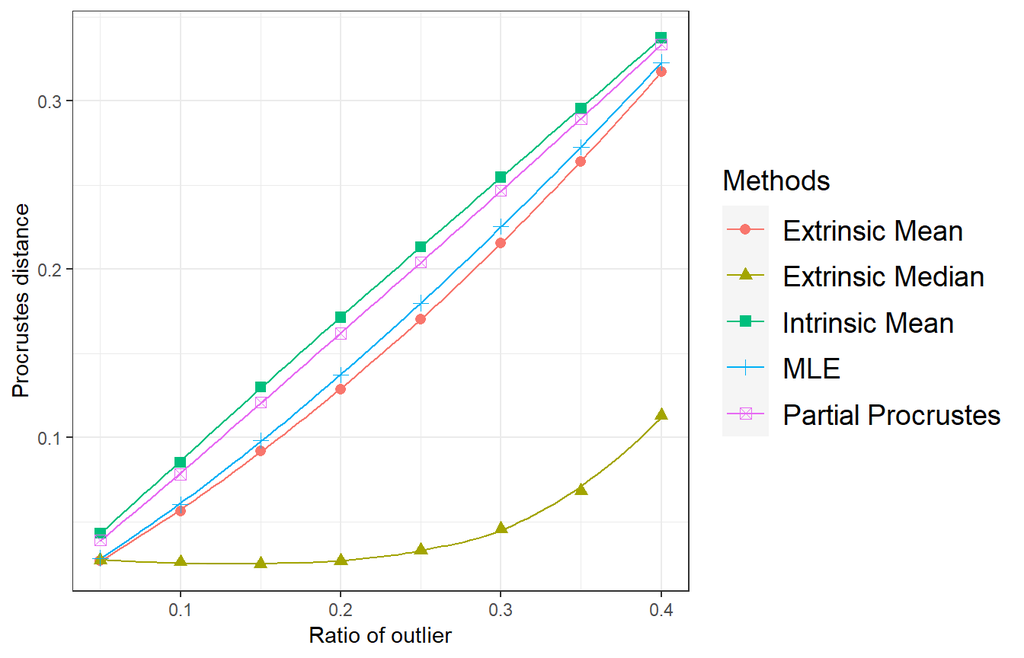

## Robust Extrinsic Local Regression (RELR)

### Method

- The population robust extrinsic regression function :
  $$\begin{align*}
  F(x) &= \operatorname{argmin}_{q \in \mathcal{M}} \int_\mathcal{M} \Vert J(q) - J(y) \Vert P(dy \vert x)\\
  &= \operatorname{argmin}_{q \in \mathcal{M}} \int_\mathcal{\widetilde{\mathcal{M}}} \Vert J(q) - z \Vert \widetilde{P}(dz \vert x) , \ \text{where}\notag
  \end{align*}$$

  $\widetilde{P}(\cdot \vert x) = P(\cdot \vert x) \circ J^{-1}$ is the conditional probability measure on $J(\mathcal{M})$ given $x$ induced by $P(\cdot \vert x)$ via embedding $J$
- **Estimation :**
  Given $\mathcal{D} = \{{\bf{x}}_i,{\bf{y}}_i\}_{i=1}^n$, where ${\bf{x}}_i \in \mathbb{R}^p, {\bf{y}}_i \in \mathcal{M}$
  $$\begin{align*}
  \hat{F}({\bf{x}}) = J^{-1} \left( \mathcal{P} \left( \operatorname{argmin}_{{\bf{y}} \in E^d} \underbrace{\sum_{i=1}^n \frac{K_H({\bf{x}}_i - {\bf{x}}) \Vert{{\bf{y}}-J({{\bf{y}}_i)\Vert}}}{\sum_{j=1}^n K_H({\bf{x}}_j - {\bf{x}})}}_{f({\bf{y}})} \right)\right)
  \end{align*}$$
  1. $K : \mathbb{R}^p \rightarrow \mathbb{R}$ s.t. $\int K(x)dx = 1$ and $\int xK(x) = 0$
  2. $H = \text{Diag} (h_1, \cdots, h_p)$ with $h_j > 0$
  3. $K_H(x) = \frac{1}{\vert H\vert} K(H^{-1}x)$, where $\vert H \vert = h_1 \cdots h_p$
- Algorithm for RELR :

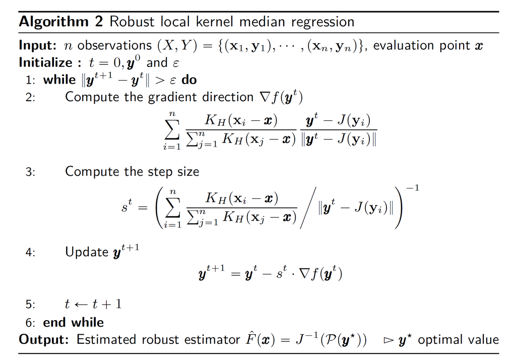

### Simulation on $\Sigma_2^k$

- Generate covariates and shapes
  $$\begin{align*}
  & \textbf{Generate Covariate :} \ X_p \sim \text{Unif}(a,b) \in \mathbb{R}^P\\[.5em]
  & \textbf{Coefficient :} \ \beta = \{1/K^2,\cdots,K/K^2\} \in \mathbb{R}^K\\[.5em]
  & \textbf{Generate Intercept angles :}\ \phi_{0k} = \{1/2,\cdots,K/2\} \\[.5em]
  & \textbf{Generate Intercept radius :}\ r_{0k} = \{0.1,\cdots,0.1\}\\[.5em]
  & \textbf{Generate Shape angles :}\ \phi_{k}^\prime \sim N\left(\phi_{0k} + \sum_{p=1}^P \beta_k X_{p}, \sigma_\phi^2\right)\\[.5em]
  & \textbf{Generate Shape radius :}\ r_{k} \sim N\left(r_{0k} + \sum_{p=1}^P \beta_k X_{p}, \sigma_r^2\right)\\[.5em]
  & \textbf{Standardize angles} : \phi_k : {\phi_k^\prime}\hspace{-.3cm}\pmod{2\pi}\\[.5em]
  & \textbf{Convert to complex form for the landmark} :
  z_k = r_k(\cos(\phi_k) + i \sin(\phi_k))
  \end{align*}$$
  - We add some outliers to some landmarks
- A Sample of the above simulation setting and fits (Univariate covariate)

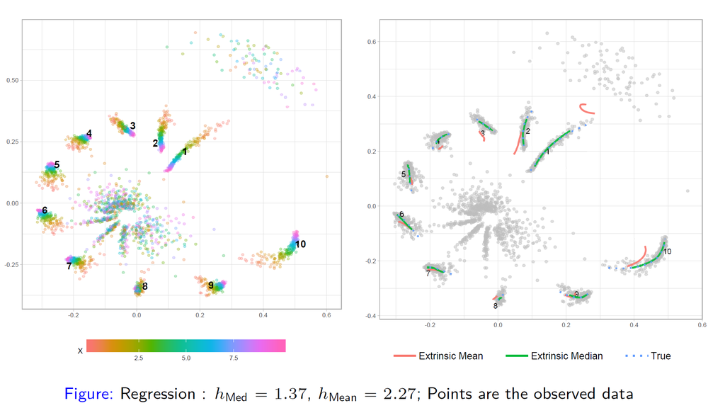

  - To ease visualize, only the first landmark is contaminated
  - Covariate values are colored in the left panel
- Result

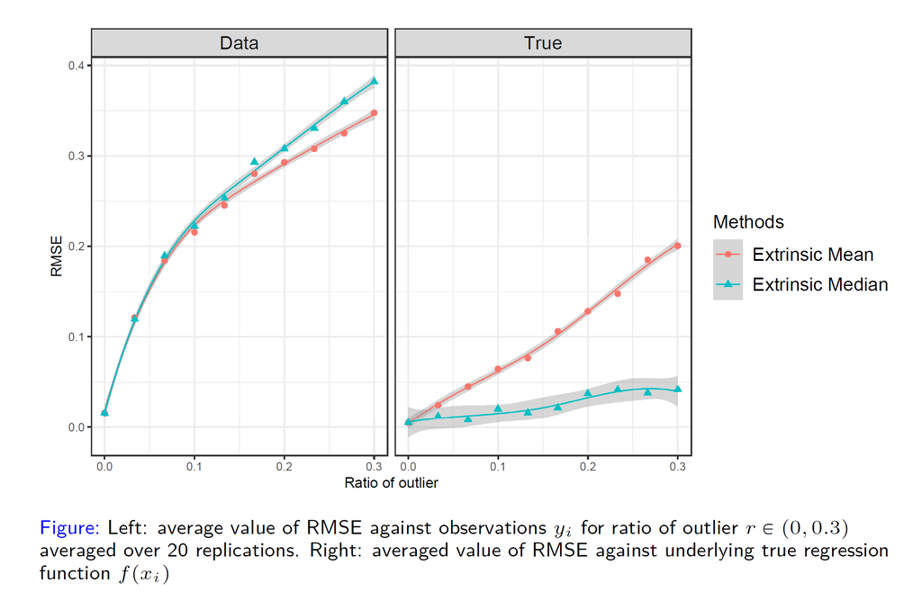